# MTH6139 Time Series

## 1.4 Visualization and Analysis

we visualize the forecast and distribution of stock prices. The **forecast plot** below illustrates the **predicted NVIDIA stock price** for the next **two** years. The plot indicates that there will be **significant increases** in the stock price, as future prices are projected to **slope upwards**.

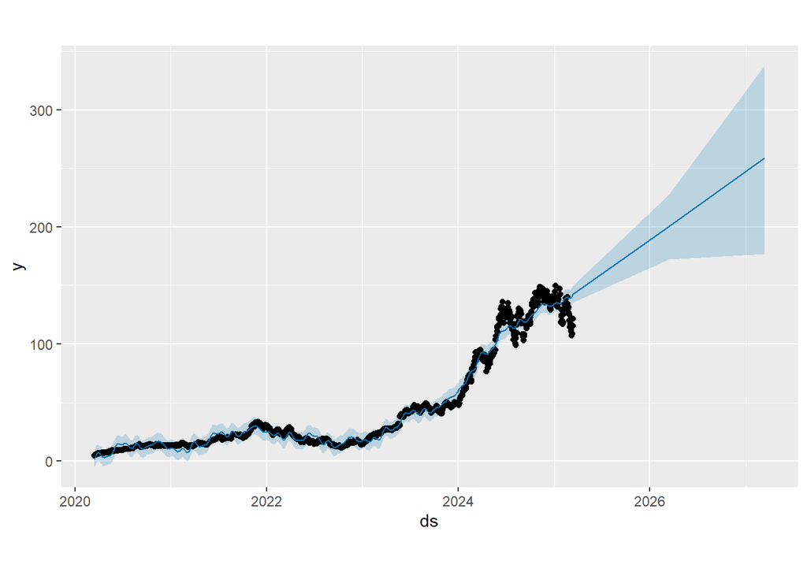

```r
#Plotting the forecast
plot(m,p,xaxis="Years",yaxis="Stock Price",main = "NVIDIA Stock Price Forecast")
```

## 1.5 Hitogram of Stock Prices

**Histogram** of stock prices as it gives us **indication of stock prices** over the period of time.we can see from the following plot that histogram is **not normally distributed**.This suggests that the dependent variable (stock prices) may be **skewed**or have a **non-normal distribution**.

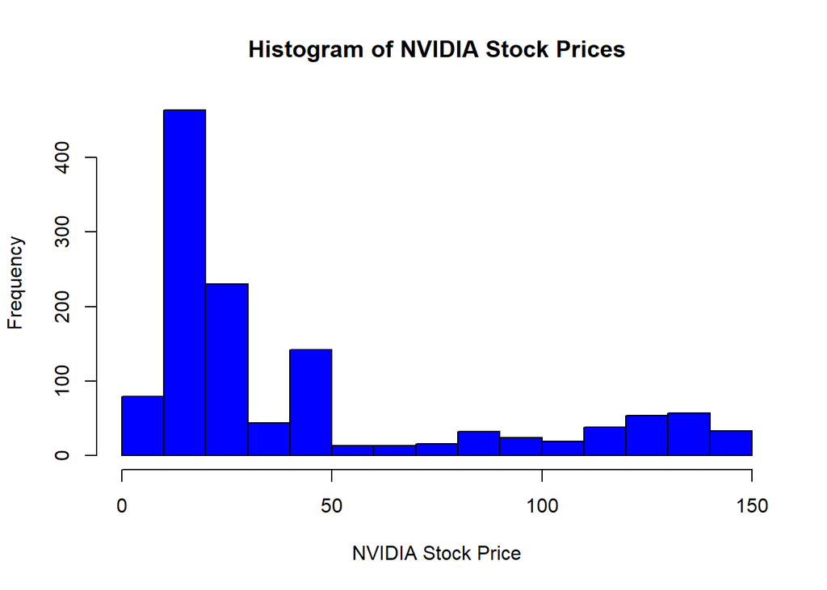

```r
#Plotting the histogram of Stock Prices
hist(Nvidia_df$y,xlab = "NVIDIA Stock Price",ylab = "Frequency",main = "Histogram of NVIDIA Stock Prices",breaks=20,col="blue")
```